# Chapter 8 Alpha diversity

We quantify within-sample diversity using Hill numbers: richness (q0), neutral/abundance-weighted (q1), phylogenetic (q1 + tree), and functional (q1 + traits), and compare these across environments and sex.

## 8.1 microbiota

**Note:** Load all required data objects including genome counts, metadata, and color schemes. Set factor levels for broad_environment variable to ensure consistent ordering.

```r
load("data/data.Rdata")
treatment_colors <- c("#f56042","#429ef5", "#42f58d", "#b142f5", "#FFA500")
sample_metadata$broad_environment <- factor(sample_metadata$broad_environment, levels=c("1000198 - Mixed forest", "1000221 - Temperate woodland", "1000218 - Xeric shrubland", "1000215 - Temperate shrubland", "1000245 - Cropland"))
```

**Note:** Filter out sample EHI01340 and filter genome counts to only include valid samples.

```r
sample_metadata <- sample_metadata %>% dplyr::filter(sample != "EHI01340")
valid_samples <- sample_metadata$sample

genome_counts_filt <- genome_counts_filt %>%
  dplyr::select(genome, tidyselect::any_of(valid_samples))
```

**Note:** Prune the phylogenetic tree to match genomes present in the filtered count data. Identifies genomes that exist in both the count data and the tree, then removes tree tips that don’t have corresponding count data.

```r
# 1) Figure out the common labels
otus  <- genome_counts_filt$genome
tips  <- genome_tree$tip.label
common <- intersect(tips, otus)

# 2) Prune the tree to only those tips
genome_tree_pruned <- drop.tip(genome_tree, setdiff(tips, common))
```

### 8.1.1 Hill numbers

Richness of microbiotic species in samples

**Note:** Calculate four types of Hill number diversity metrics for each sample: richness (q=0, species count unweighted by abundance), neutral (q=1, Shannon diversity abundance-weighted), phylogenetic (q=1 + tree, incorporates phylogenetic relationships), and functional (q=1 + traits, incorporates functional trait distances). Then merge all metrics into a single alpha_div dataframe.

```r
# Calculate Hill numbers
richness <- genome_counts_filt %>%
  column_to_rownames(var = "genome") %>%
  dplyr::select(where(~ !all(. == 0))) %>%
  hilldiv(., q = 0) %>%
  t() %>%
  as.data.frame() %>%
  dplyr::rename(richness = 1) %>%
  rownames_to_column(var = "sample")

neutral <- genome_counts_filt %>%
  column_to_rownames(var = "genome") %>%
  dplyr::select(where(~ !all(. == 0))) %>%
  hilldiv(., q = 1) %>%
  t() %>%
  as.data.frame() %>%
  dplyr::rename(neutral = 1) %>%
  rownames_to_column(var = "sample")

phylogenetic <- genome_counts_filt %>%
  column_to_rownames(var = "genome") %>%
  dplyr::select(where(~ !all(. == 0))) %>%
  hilldiv(., q = 1, tree = genome_tree_pruned) %>%
  t() %>%
  as.data.frame() %>%
  dplyr::rename(phylogenetic = 1) %>%
  rownames_to_column(var = "sample")

# Aggregate basal GIFT into elements
dist <- genome_gifts %>%
  to.elements(., GIFT_db) %>%
  traits2dist(., method = "gower")

functional <- genome_counts_filt %>%
  filter(genome %in% rownames(dist)) %>%
  arrange(match(genome, rownames(dist))) %>%
  column_to_rownames(var = "genome") %>%
  dplyr::select(where(~ !all(. == 0))) %>%
  hilldiv(., q = 1, dist = dist) %>%
  t() %>%
  as.data.frame() %>%
  dplyr::rename(functional = 1) %>%
  rownames_to_column(var = "sample") %>%
  filter(!is.nan(functional), !is.na(functional))

# Merge all metrics
alpha_div <- richness %>%
  full_join(neutral, by = join_by(sample == sample)) %>%
  full_join(phylogenetic, by = join_by(sample == sample)) %>%
  full_join(functional, by = join_by(sample == sample))
```

**Note:** Create a summary statistics table showing mean ± SD for each alpha diversity metric. Calculates overall statistics and statistics by environment type, formats results as “mean±sd” strings, and displays results in a formatted table.

| alpha | Total | Xeric_shrubland | Temperate_woodland | Temperate_shrubland | Cropland | Mixed_forest |
| --- | --- | --- | --- | --- | --- | --- |
| richness | 307.14±137.95 | 331.67±156.38 | 290.87±124.42 | 269.67±72.29 | 423.73±156.53 | 196.6±87.35 |
| neutral | 115.2±68.51 | 125.56±81.45 | 115.36±64.88 | 111.51±39.34 | 143.35±80.62 | 41.57±21.29 |
| phylogenetic | 7.35±1.43 | 7.66±1.29 | 7.17±1.38 | 6.23±0.91 | 8.68±0.97 | 6.41±1.48 |
| functional | 1.44±0.05 | 1.4±0.04 | 1.45±0.06 | 1.44±0.04 | 1.44±0.04 | 1.42±0.04 |

Richness of microbiotic species - environment clusters

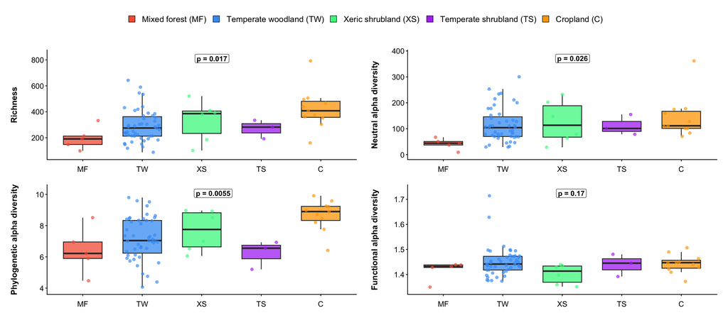

```r
#Richness

env_limits <- c(
  "1000198 - Mixed forest",
  "1000221 - Temperate woodland",
  "1000218 - Xeric shrubland",
  "1000215 - Temperate shrubland",
  "1000245 - Cropland"
)

env_labels_short <- c("MF","TW","XS","TS","C")
env_labels_long <- c(
  "1000198 - Mixed forest"        = "Mixed forest (MF)",
  "1000221 - Temperate woodland"  = "Temperate woodland (TW)",
  "1000218 - Xeric shrubland"     = "Xeric shrubland (XS)",
  "1000215 - Temperate shrubland" = "Temperate shrubland (TS)",
  "1000245 - Cropland"            = "Cropland (C)"
)

make_plot <- function(target_metric, ylab){
  alpha_div %>%
    pivot_longer(-sample, names_to = "metric", values_to = "value") %>%
    inner_join(sample_metadata, by = dplyr::join_by(sample == sample)) %>%
    filter(metric == target_metric) %>%
    ggplot(aes(x = broad_environment, y = value)) +
    geom_boxplot(aes(fill = broad_environment),
                 width = 0.65, alpha = 0.75, outlier.shape = NA,
                 show.legend = TRUE, linewidth = 0.6) +
    geom_jitter(aes(color = broad_environment),
                width = 0.3, size = 1.8, alpha = 0.65,
                show.legend = FALSE) +
    scale_fill_manual(values = treatment_colors, labels = env_labels_long,
                      breaks = env_limits, drop = FALSE) +
    scale_color_manual(values = treatment_colors, guide = "none") +
    scale_x_discrete(limits = env_limits, labels = env_labels_short, drop = FALSE) +
    # p-value: white label at the very top of the panel
    stat_compare_means(method = "kruskal.test", label = "p.format",
                       geom = "label", fill = "white", label.size = 0.4,
                       label.padding = unit(0.2, "lines"),
                       label.r = unit(0.15, "lines"),
                       color = "black",
                       label.y.npc = 0.98, label.x = 3, size = 4, fontface = "bold") +
    scale_y_continuous(expand = expansion(mult = c(0.08, 0.12))) +
    coord_cartesian(clip = "off") +
    theme_classic() +
    theme(
      legend.title = element_blank(),
      legend.text = element_text(size = 11),
      legend.position = "top",
      legend.margin = margin(b = 6, t = 0),
      legend.key.size = unit(0.8, "lines"),
      legend.spacing.x = unit(0.3, "cm"),
      legend.box.margin = margin(b = 5),
      axis.title.x = element_blank(),
      axis.text.x = element_text(size = 12, angle = 0, hjust = 0.5,
                                 margin = margin(t = 8)),
      axis.text.y = element_text(size = 12),
      axis.title.y = element_text(size = 13, margin = margin(r = 20), face = "bold"),
      plot.margin = margin(t = 8, r = 12, b = 10, l = 12),
      panel.spacing = unit(1.2, "lines")
    ) +
    labs(y = ylab)
}

plot1 <- make_plot("richness",      "Richness")
plot2 <- make_plot("neutral",       "Neutral alpha diversity")
plot3 <- make_plot("phylogenetic",  "Phylogenetic alpha diversity")
plot4 <- make_plot("functional",    "Functional alpha diversity")

# >>> Plots without legends <<<
# Remove legends from individual plots
plot1_no_legend <- plot1 + theme(legend.position = "none")
plot2_no_legend <- plot2 + theme(legend.position = "none")
plot3_no_legend <- plot3 + theme(legend.position = "none")
plot4_no_legend <- plot4 + theme(legend.position = "none")

# Combine plots without legends
plots_combined <- (plot1_no_legend + plot2_no_legend + plot3_no_legend + plot4_no_legend) +
  plot_layout(ncol = 2, widths = c(1, 1), heights = c(1, 1))

# Create the legend
legend_data <- data.frame(
  environment = factor(env_limits, levels = env_limits),
  x = 1:5,
  y = 1
)

alpha_div_legend <- ggplot(legend_data, aes(x = x, y = y, fill = environment)) +
  geom_point(shape = 22, size = 8, show.legend = TRUE) +
  scale_fill_manual(
    values = treatment_colors,
    labels = env_labels_long,
    breaks = env_limits,
    drop = FALSE,
    name = NULL
  ) +
  theme_void() +
  theme(
    legend.position = "top",
    legend.direction = "horizontal",
    legend.justification = "center",
    legend.text = element_text(size = 13),
    legend.key.size = unit(1.5, "lines"),
    legend.spacing.x = unit(0.8, "cm"),
    legend.margin = margin(b = 15, t = 10),
    plot.margin = margin(t = 10, b = 5, l = 0, r = 0)
  ) +
  guides(fill = guide_legend(override.aes = list(size = 5)))

# Combine legend on top with plots below
final_plot <- cowplot::plot_grid(
  alpha_div_legend,
  plots_combined,
  ncol = 1,
  rel_heights = c(0.15, 1),
  align = "v"
)

final_plot
```

Richness of microbiotic species - sex clusters

**Note:** Create boxplots comparing alpha diversity metrics by sex, faceted by environment. Defines color scheme for sex categories, creates a plotting function that facets by environment, generates four plots (richness, neutral, phylogenetic, functional), combines plots into a 2x2 grid with shared legend, and includes Wilcoxon test p-values comparing Female vs Male within each environment.

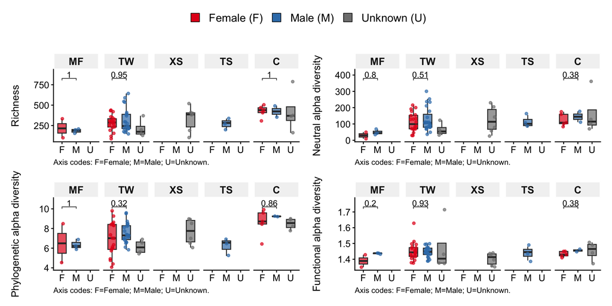

```r
# colors (keep or replace)
sex_colors <- c("Female" = "#E41A1C", "Male" = "#377EB8", "Unknown" = "grey50")

make_plot_sex <- function(target_metric, ylab) {
  alpha_div %>%
    pivot_longer(-sample, names_to = "metric", values_to = "value") %>%
    inner_join(sample_metadata, by = dplyr::join_by(sample == sample)) %>%
    filter(metric == target_metric) %>%
    mutate(
      # ensure order + map short ticks
      sex = factor(sex, levels = c("Female","Male","Unknown"))
    ) %>%
    ggplot(aes(x = sex, y = value, fill = sex)) +
    geom_boxplot(width = 0.6, alpha = 0.7, outlier.shape = NA,
                 show.legend = TRUE, linewidth = 0.5) +
    geom_jitter(aes(color = sex), width = 0.2, size = 1.3, alpha = 0.7,
                show.legend = FALSE) +
    facet_grid(
      ~ broad_environment,
      labeller = labeller(broad_environment = c(
        "1000198 - Mixed forest"       = "MF",
        "1000221 - Temperate woodland" = "TW",
        "1000218 - Xeric shrubland"    = "XS",
        "1000215 - Temperate shrubland" = "TS",
        "1000245 - Cropland"           = "C"
      )),
      scales = "fixed", space = "free_x"
    ) +
    # p-values: readable white labels at the top of each facet
    ggpubr::stat_compare_means(
      method = "wilcox.test",
      comparisons = list(c("Female","Male")),
      label = "p.format",
      geom = "label", fill = "white", color = "black",
      label.size = 0.3, label.padding = grid::unit(0.15, "lines"),
      label.r = grid::unit(0.1, "lines"),
      label.y.npc = 0.98, label.x.npc = 0.5, size = 3.5, fontface = "bold"
    ) +
    # SHORT x-ticks + legend with full names
    scale_x_discrete(labels = c(Female = "F", Male = "M", Unknown = "U")) +
    scale_fill_manual(
      values = sex_colors,
      labels = c("Female (F)", "Male (M)", "Unknown (U)")
    ) +
    scale_color_manual(values = sex_colors, guide = "none") +
    scale_y_continuous(expand = expansion(mult = c(0.05, 0.15))) +
    coord_cartesian(clip = "off") +
    theme_classic() +
    theme(
      legend.position = "top",
      legend.title = element_blank(),
      legend.text = element_text(size = 11),
      legend.margin = margin(b = 8),
      strip.background = element_rect(fill = "grey95", color = "white"),
      strip.text = element_text(size = 12, face = "bold", margin = margin(4, 0, 4, 0)),
      axis.title.x = element_blank(),
      axis.text.x = element_text(size = 11),
      axis.text.y = element_text(size = 11),
      axis.title.y = element_text(size = 12, margin = margin(r = 15)),
      plot.margin = margin(t = 10, r = 8, b = 8, l = 8),
      plot.caption = element_text(size = 9, hjust = 0, margin = margin(t = 5))
    ) +
    labs(
      y = ylab,
      caption = "Axis codes: F=Female; M=Male; U=Unknown."
    )
}

plot1 <- make_plot_sex("richness",      "Richness")
plot2 <- make_plot_sex("neutral",       "Neutral alpha diversity")
plot3 <- make_plot_sex("phylogenetic",  "Phylogenetic alpha diversity")
plot4 <- make_plot_sex("functional",    "Functional alpha diversity")

# Remove legends from individual plots
plot1_no_legend <- plot1 + theme(legend.position = "none")
plot2_no_legend <- plot2 + theme(legend.position = "none")
plot3_no_legend <- plot3 + theme(legend.position = "none")
plot4_no_legend <- plot4 + theme(legend.position = "none")

# Combine plots without legends
plots_combined_sex <- (plot1_no_legend + plot2_no_legend + plot3_no_legend + plot4_no_legend) +
  plot_layout(ncol = 2, widths = c(1, 1), heights = c(1, 1))

# Create the legend for sex categories
legend_data_sex <- data.frame(
  sex = factor(c("Female", "Male", "Unknown"), levels = c("Female", "Male", "Unknown")),
  x = 1:3,
  y = 1
)

alpha_div_legend_sex <- ggplot(legend_data_sex, aes(x = x, y = y, fill = sex)) +
  geom_point(shape = 22, size = 8, show.legend = TRUE) +
  scale_fill_manual(
    values = sex_colors,
    labels = c("Female (F)", "Male (M)", "Unknown (U)"),
    breaks = c("Female", "Male", "Unknown"),
    name = NULL
  ) +
  theme_void() +
  theme(
    legend.position = "top",
    legend.direction = "horizontal",
    legend.justification = "center",
    legend.text = element_text(size = 13),
    legend.key.size = unit(1.5, "lines"),
    legend.spacing.x = unit(0.8, "cm"),
    legend.margin = margin(b = 15, t = 10),
    plot.margin = margin(t = 10, b = 5, l = 0, r = 0)
  ) +
  guides(fill = guide_legend(override.aes = list(size = 5)))

# Combine legend on top with plots below
final_plot_sex <- cowplot::plot_grid(
  alpha_div_legend_sex,
  plots_combined_sex,
  ncol = 1,
  rel_heights = c(0.15, 1),
  align = "v"
)

final_plot_sex
```

### 8.1.2 Mixed models

**Note:** Fit linear mixed-effects models (LME) and linear models (LM) for each alpha diversity metric. Merges alpha diversity with sample metadata and filters complete cases. For environment effects, **region** is the random intercept (sampling locality); for sex effects, **broad_environment** is the random intercept. Pairwise sex comparisons use `emmeans` on the sex LME.

```r
alpha_div_meta <- alpha_div %>%
  inner_join(sample_metadata, by = join_by(sample == sample))

alpha_div_meta_clean <- alpha_div_meta %>%
  filter(!is.na(richness), !is.na(broad_environment), !is.na(sex), !is.na(region))

Model_richness_random <- lme(
  fixed = richness ~ broad_environment,
  data = alpha_div_meta_clean,
  random = ~ 1 | region
)
anova(Model_richness_random)
```

```
                  numDF denDF   F-value p-value
(Intercept)           1    52 122.55311  <.0001
broad_environment     4    52   2.73979  0.0383
```

```r
Model_richness <- lm(
  formula = richness ~ broad_environment + sex,
  data = alpha_div_meta_clean
)
anova(Model_richness)
```

```
Analysis of Variance Table

Response: richness
                  Df  Sum Sq Mean Sq F value  Pr(>F)
broad_environment  4  230874   57718  3.4242 0.01331 *
sex                2   24662   12331  0.7315 0.48509
Residuals         65 1095649   16856
---
Signif. codes:  0 '***' 0.001 '**' 0.01 '*' 0.05 '.' 0.1 ' ' 1
```

```r
Model_richness_sex_random <- lme(
  fixed = richness ~ sex,
  data = alpha_div_meta_clean,
  random = ~ 1 | broad_environment
)
anova(Model_richness_sex_random)
```

```
            numDF denDF  F-value p-value
(Intercept)     1    65 53.20316  <.0001
sex             2    65  0.26214  0.7702
```

```r
emmeans(Model_richness_sex_random, pairwise ~ sex)
```

```
$emmeans
 sex     emmean   SE df lower.CL upper.CL
 Female     306 48.7  4      171      441
 Male       323 47.0  4      192      453
 Unknown    288 54.0  4      139      438

Degrees-of-freedom method: containment
Confidence level used: 0.95

$contrasts
 contrast         estimate   SE df t.ratio p.value
 Female - Male       -16.8 35.0 65  -0.480  0.8811
 Female - Unknown     17.6 50.4 65   0.350  0.9348
 Male - Unknown       34.4 50.8 65   0.678  0.7774

Degrees-of-freedom method: containment
P value adjustment: tukey method for comparing a family of 3 estimates
```

```r
alpha_div_neutral_clean <- alpha_div_meta %>%
  filter(!is.na(neutral), !is.na(broad_environment), !is.na(sex), !is.na(region))

Model_neutral_random <- lme(
  fixed = neutral ~ broad_environment,
  data = alpha_div_neutral_clean,
  random = ~ 1 | region
)
anova(Model_neutral_random)
```

```
                  numDF denDF  F-value p-value
(Intercept)           1    52 64.33793  <.0001
broad_environment     4    52  1.48326  0.2207
```

```r
Model_neutral <- lm(
  formula = neutral ~ broad_environment + sex,
  data = alpha_div_neutral_clean
)
anova(Model_neutral)
```

```
Analysis of Variance Table

Response: neutral
                  Df Sum Sq Mean Sq F value  Pr(>F)
broad_environment  4  36511  9127.8  2.0483 0.09788 .
sex                2   7054  3527.0  0.7915 0.45750
Residuals         65 289656  4456.2
---
Signif. codes:  0 '***' 0.001 '**' 0.01 '*' 0.05 '.' 0.1 ' ' 1
```

```r
Model_neutral_sex_random <- lme(
  fixed = neutral ~ sex,
  data = alpha_div_neutral_clean,
  random = ~ 1 | broad_environment
)
anova(Model_neutral_sex_random)
```

```
            numDF denDF  F-value p-value
(Intercept)     1    65 40.93807  <.0001
sex             2    65  0.40680  0.6675
```

```r
emmeans(Model_neutral_sex_random, pairwise ~ sex)
```

```
$emmeans
 sex     emmean   SE df lower.CL upper.CL
 Female     103 21.1  4     44.4      162
 Male       119 20.2  4     62.8      175
 Unknown    107 24.1  4     40.6      174

Degrees-of-freedom method: containment
Confidence level used: 0.95

$contrasts
 contrast         estimate   SE df t.ratio p.value
 Female - Male      -15.93 17.9 65  -0.889  0.6491
 Female - Unknown    -4.37 25.1 65  -0.174  0.9834
 Male - Unknown      11.56 25.1 65   0.460  0.8901

Degrees-of-freedom method: containment
P value adjustment: tukey method for comparing a family of 3 estimates
```

```r
alpha_div_phylo_clean <- alpha_div_meta %>%
  filter(!is.na(phylogenetic), !is.na(broad_environment), !is.na(sex), !is.na(region))

Model_phylogenetic_random <- lme(
  fixed = phylogenetic ~ broad_environment,
  data = alpha_div_phylo_clean,
  random = ~ 1 | region
)
anova(Model_phylogenetic_random)
```

```
                  numDF denDF  F-value p-value
(Intercept)           1    52 672.3287  <.0001
broad_environment     4    52   3.7655  0.0092
```

```r
Model_phylogenetic <- lm(
  formula = phylogenetic ~ broad_environment + sex,
  data = alpha_div_phylo_clean
)
anova(Model_phylogenetic)
```

```
Analysis of Variance Table

Response: phylogenetic
                  Df  Sum Sq Mean Sq F value   Pr(>F)
broad_environment  4  29.610  7.4025  4.4653 0.002997 **
sex                2   7.726  3.8632  2.3303 0.105340
Residuals         65 107.756  1.6578
---
Signif. codes:  0 '***' 0.001 '**' 0.01 '*' 0.05 '.' 0.1 ' ' 1
```

```r
Model_phylogenetic_sex_random <- lme(
  fixed = phylogenetic ~ sex,
  data = alpha_div_phylo_clean,
  random = ~ 1 | broad_environment
)
anova(Model_phylogenetic_sex_random)
```

```
            numDF denDF   F-value p-value
(Intercept)     1    65 177.59897  <.0001
sex             2    65   1.48681  0.2337
```

```r
emmeans(Model_phylogenetic_sex_random, pairwise ~ sex)
```

```
$emmeans
 sex     emmean    SE df lower.CL upper.CL
 Female    7.21 0.600  4     5.54     8.87
 Male      7.65 0.585  4     6.02     9.27
 Unknown   6.84 0.647  4     5.04     8.64

Degrees-of-freedom method: containment
Confidence level used: 0.95

$contrasts
 contrast         estimate    SE df t.ratio p.value
 Female - Male      -0.439 0.349 65  -1.258  0.4237
 Female - Unknown    0.371 0.515 65   0.720  0.7526
 Male - Unknown      0.810 0.522 65   1.550  0.2748

Degrees-of-freedom method: containment
P value adjustment: tukey method for comparing a family of 3 estimates
```

```r
alpha_div_functional_clean <- alpha_div_meta %>%
  filter(!is.na(functional), !is.na(broad_environment), !is.na(sex), !is.na(region))

Model_functional_random <- lme(
  fixed = functional ~ broad_environment,
  data = alpha_div_functional_clean,
  random = ~ 1 | region
)
anova(Model_functional_random)
```

```
                  numDF denDF   F-value p-value
(Intercept)           1    52 17661.434  <.0001
broad_environment     4    52     0.382  0.8205
```

```r
Model_functional <- lm(
  formula = functional ~ broad_environment + sex,
  data = alpha_div_functional_clean
)
anova(Model_functional)
```

```
Analysis of Variance Table

Response: functional
                  Df   Sum Sq   Mean Sq F value Pr(>F)
broad_environment  4 0.015996 0.0039991  1.3366 0.2659
sex                2 0.002703 0.0013515  0.4517 0.6385
Residuals         65 0.194480 0.0029920
```

```r
Model_functional_sex_random <- lme(
  fixed = functional ~ sex,
  data = alpha_div_functional_clean,
  random = ~ 1 | broad_environment
)
anova(Model_functional_sex_random)
```

```
            numDF denDF   F-value p-value
(Intercept)     1    65 19304.520  <.0001
sex             2    65     0.016  0.9838
```

```r
emmeans(Model_functional_sex_random, pairwise ~ sex)
```

```
$emmeans
 sex     emmean     SE df lower.CL upper.CL
 Female    1.43 0.0139  4     1.40     1.47
 Male      1.44 0.0132  4     1.40     1.47
 Unknown   1.44 0.0167  4     1.39     1.48

Degrees-of-freedom method: containment
Confidence level used: 0.95

$contrasts
 contrast         estimate     SE df t.ratio p.value
 Female - Male    -0.00234 0.0145 65  -0.161  0.9858
 Female - Unknown -0.00266 0.0194 65  -0.137  0.9897
 Male - Unknown   -0.00032 0.0192 65  -0.017  0.9998

Degrees-of-freedom method: containment
P value adjustment: tukey method for comparing a family of 3 estimates
```